# Análisis exploratorio de la encuesta inicial

Simón Cuartas Rendón

Danilo Isaac García Castaño

David Mateo García Vallejo

Luis Miguel Martínez Escobar

Miércoles, 14 de abril de 2021

## Introducción

La estadística es una herramienta bastante útil y con una creciente demanda, pues estamos constantemente rodeados por millones de datos que pueden ser traducidos a información importante si son tratados de la manera adecuada, y para ello es imprescindible comenzar con una fase exploratoria y descriptiva en la cual se comienzan a manipular los datos, entenderlos, realizar procesos de depuración de ser necesario y generar resúmenes estadísticos y gráficos, entre otros, con la finalidad de comprenderlos mejor y poder realizar de forma más adecuada otras actividades como las inferenciales y las predictivas.

Así, lenguajes de programación como R, con sus múltiples librerías, se convierten en una gran opción con la cual se puede realizar de forma ágil y elegante la exploración y descripción de los datos. Es por ello que en este trabajo se pondrá en práctica los conceptos, metodologías y las funciones y tips de R aprendidas en el curso de **Estadística Descriptiva y Análisis Exploratorio de Datos** (en adelante EDAED) a partir de una encuesta realizada a los estudiantes de esta materia.

Es importante aclarar que este trabajo ha sido planteado para que pueda ser leído por cualquier tipo de público, de modo que es explícito en cada uno de los procedimientos y conclusiones que se sacan, en el sentido que se explica todo con el mayor detalle posible y se trata de presentar la información de la manera más expedita posible.

## Depuración y ajuste de la base de datos

Para este proceso se tomó cada una de las variables de la base de datos y se estudió si los valores incluidos tenían sentido en su propio contexto. Además, **se crearon algunas variables adicionales** con el fin de analizar interrogantes que no podrían resolverse directamente con las variables existentes o para facilitar la comprensión de algunas otras. Es importante anotar que solo se hará mención de aquellas variables en las que se realizó alguna depuración o que fueron introducidas. También se mencionarán algunos cambios en la presentación de algunas variables categóricas de cara a la presentación al lector.

Es importante aclarar que en este trabajo no se le asignaron valores a los diferentes *NA* que se hallaron y se optó más bien por realizar los procesos descriptivos con aquellos valores definidos; esto con la finalidad de no alterar la información que se pudiese obtener a partir de ellas y no introducir posibles errores mediante una depuración equívoca.

### Primera sección de la encuesta: preguntas de caracterización

##### **Género:**

En este caso se va a realizar un renombramiento de las categorías que conforman esta variable de modo que su lectura se facilite para el lector.

##### **Edad:**

Se crea la variable *edad*, pues resulta más sencillo hacer análisis etarios con el valor de la edad en comparación con la fecha de nacimiento. Es importante notar que para el cálculo de esta se tomó la edad de los estudiantes del curso de EDAED al momento de realizar la encuesta, que fue el 26 de febrero de 2021.

##### **Tiempo empleado para la realización de la encuesta:**

Otra variable interesante, en especial para el análisis de las preguntas de la tercera sección de preguntas (áreas y propiedades de los reales) está relacionada con el tiempo empleado, en minutos, para la realización de la encuesta, por lo que se crea esta variable *tiempo usado* de acuerdo a la fecha de envío de la encuesta.

##### **Carrera:**

Se eliminó el número asociado a cada una de las respuestas, pues este no está dando información adicional o relevante, considerando especialmente que se trata de variables categóricas. Así, por ejemplo, se cambio *‘1 : Matemáticas’* por *‘Matemáticas’*.

##### **Avance:**

Entre los estudiantes es común hacer una diferencia entre los conceptos de **semestre** y **avance**, siendo el primero una referencia del número de matrículas que tiene un estudiante en la universidad y el segundo el porcentaje de créditos aprobados sobre la cantidad de créditos que deben aprobarse para egresar. En este sentido, se creó la varible *avance* que representa este valor de una forma más comprensible, con una ligera transformación en su definición, y es que entenderá como el cociente de la suma estima de los créditos aprobados de momento y matriculados en el semestre 2021-1S entre la cantidad total de créditos de la carrera.

##### **Puntaje en las pruebas Saber 11:**

Para entender esta variable es útil tener presente que a lo largo de la historia de esta prueba, el valor más bajo posible ha sido cero, mientras que el más alto ha sido quinientos. De este modo, se puede observar en el siguiente gráfico de dispersión que existe una entrada que superó el puntaje máximo (con número de respuesta 2493) y otros dos que tienen justo el puntaje mínimo (con números de respuesta 2505 y 2487).

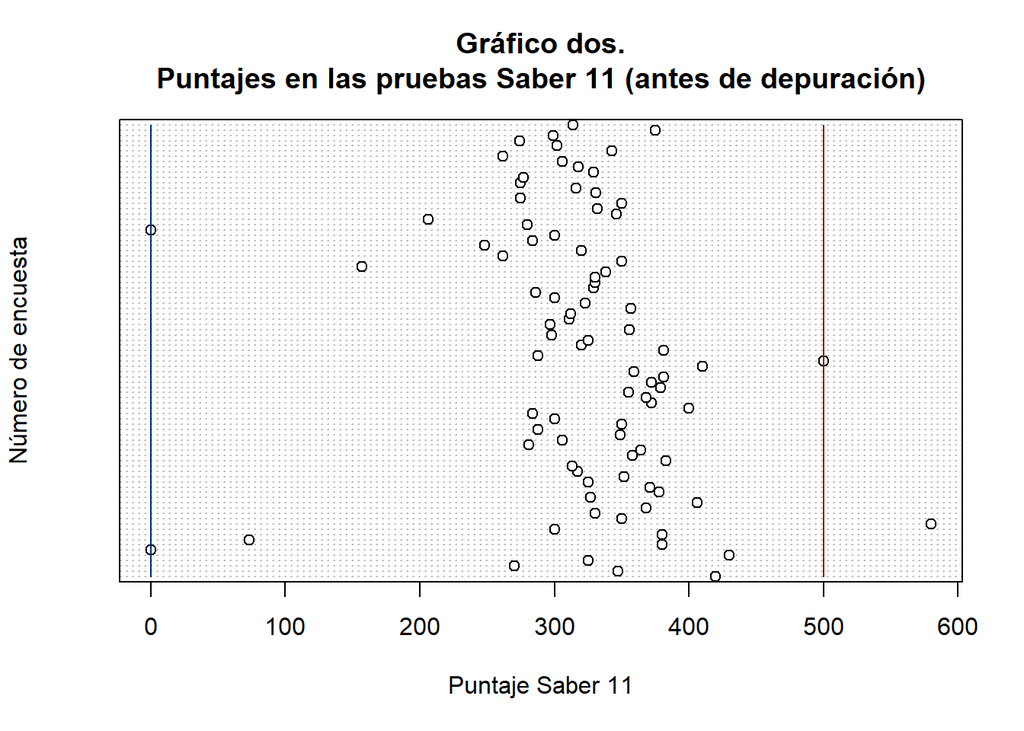

En este, claramente no tiene sentido obtener un puntaje de 580, máxime en el año 2009 (en el cual la persona que dice tener tal puntaje presentó el examen) cuando el puntaje máximo correspondía a 400 puntos), y como no existe ningún valor coherente posible para imputar de forma directa este valor, entonces se opta por descartarlo de la base de datos y convertirlo en un *NA*.

En el caso de los ceros, se presentan dos casos diferentes: en el primero (con código de respuesta 2505) se tiene que la persona presentó el examen de Estado en el año 1999, en el cual el puntaje mínimo era de cien puntos, por lo que se le imputará un *NA* a este cero; sin embargo, para el cero asociado a la respuesta número 2487, como esta persona rindió el test en el 2019, cuando sí era posible obtener un puntaje nulo, entonces el valor se mantendrá [1].

##### **Percentil en las pruebas Saber 11:**

[figure not shown]

##### **Fecha de presentación de la prueba Saber 11:**

Observando la información resumen asociada a esta variable, se identificó una entrada en la que se propone la fecha de presentación el 8 de agosto de 2021, la cual aún no sucede, por lo que será tomada como un *NA*, considerando que otros posibles valores como 2020-08-08 no pueden ser asumidos, teniendo en cuenta que en el 2020 el ICFES fue en el mes de noviembre y que no existe ningún otro error tipográfico asociado al 2021 (pues el 2020 como ya vimos se descarta y los siguientes años aún no suceden).

##### **PAPA:**

En el caso del PAPA, es bien sabido que los valores posibles están en el intervalo [0, 5] con una cifra decimal de precisión; pero al realizar un diagrama de puntos para esta variable se puede identificar rápidamente una respuesta no acorde, pues da un valor de 45 (respuesta 2494). Así, para este caso, tiene sentido pensar que la persona olvidó incluir el punto decimal en su respuesta, por lo que se le da un PAPA de 4.5.

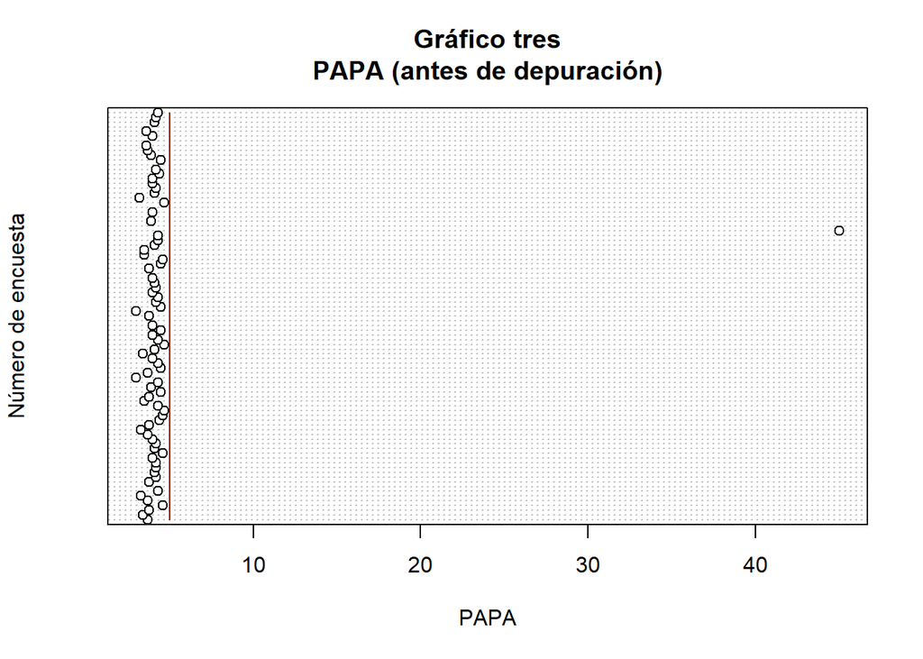

##### **Estrato:**

Para esta variable simplemente se realizó un cambio en el nombre de las categorías con la finalidad de hacerlo más legible para el lector. Así, por ejemplo, se cambió *2 : 1* por *1*.

##### **Recursos tecnológicos**

Para el análisis exploratorio se decidieron crear dos nuevas variables, una relacionada con los recursos tecnológicos propios (o con datos) y otra con los recursos tecnológicos no propios (o sin datos), donde se almacenará el número de recursos tecnológicos de dicho tipo con que cuentan los encuestados. El máximo valor que pueden tener estas variables es de 7, debido a que este es el número de opciones de dichos tipos que había disponible en la encuesta; mientras que el mínimo será de 0. Después de la creación de esta variable se reemplazan las respuestas individuales de cada recurso tecnológico de la siguiente manera: Un “1” por un *“Si”* y un “0” por un *“No”*. Esto es simplemente para facilitar su análisis descriptivo.

### Segunda sección: conspiraciones

Para el análisis exploratorio se decidió crear una nueva variable llamada *numero_conspiraciones*, donde se almacenará el número de conspiraciones falsas en que creen los encuestados. El máximo valor que tendrá esta variable es de 5, mientras que el mínimo será de 0. Después de la creación de esta variable se reemplazan las respuestas individuales de conspiraciones de la siguiente manera: Un “1” por un *“Si”* y un “0” por un *“No”*. Esto es simplemente para facilitar su respectivo análisis descriptivo.

### Tercera sección: álgebra y percepción grupal

##### **Área sombreada:**

En esta pregunta se realizó una nueva reformulación de las diferentes categorías para lograr hacerlas más legibles. Así, por ejemplo, se cambio *1 : 7.5*pi* por un *7.5*pi*

##### **Porcentaje de estudiantes que se cree que respondieron bien la pregunta del área:**

Para esta pregunta, se asume que el valor que debió haber sido ingresado era un número del cero al cien que representaba un porcentaje. En este sentido, si bien un valor menor a uno tendría a cero (pues está dentro del rango permitido de valores), este no tiene mucho sentido considerando el tamaño del grupo. Así, se puede pensar que la persona con respuesta 2461 que introdujo como respuesta en realidad quería plantear que un diez por ciento (10 %) de los estudiantes del EDAED contestarían bien tal pregunta.

##### **Divisores**

Dado que esta pregunta era de múltiple respuesta y tenía tres opciones de respuesta, además que las tres opciones eran correctas y por lo tanto para haber respondido acertadamente es su totalidad había que elegir las tres opciones, se decidió crear una nueva variable llamada *opciones_divisor* para así ver cuántos estudiantes contestaron correctamente esta pregunta. La variable almacenará la cantidad de opciones que los estudiantes eligieron, siendo la mínima cantidad de 0 y la máxima cantidad de 3.

##### **Porcentaje de estudiantes que se cree que respondieron bien la pregunta de álgebra:**

Nuevamente, para el encuestado con respuesta 2461, se va a imputar su valor con una lógica semejante a la anterior, cambiando el 0.50 por un 50.

## Análisis descriptivo

*Observación. La numeración de las preguntas no coincide con la de la encuesta original, en tanto existen varias preguntas que son analizadas en grupos.*

### Primera parte de la encuesta

A continuación se presenta el análisis descriptivo de la primera sección de preguntas de la encuesta, la cual consiste de preguntas de caracterización del estudiante.

#### 1. Tiempo empleado en responder la encuesta

Como anteriormente se había dicho, para analizar la fecha de envío de la encuesta se usará una nueva variable correspondiente al tiempo usado en minutos para responder la encuesta. Se ve que en promedio los estudiantes del curso respondieron la encuesta en 16.24 minutos, donde el que la envió de primero usó un tiempo de 5.03 minutos y el que la envió de último usó un tiempo de 28.93 minutos. En la gráfica también se puede ver que la mayoría de estudiantes usaron entre 10 y 20 minutos para responder la encuesta.

```
##    Min. 1st Qu.  Median    Mean 3rd Qu.    Max.
##    5.03   13.03   15.82   16.24   19.52   28.93
```

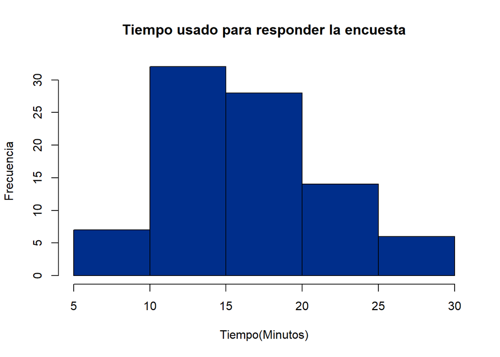

#### 2. Género

La variable **género** se constituye como una variable categórica con un orden de medición nominal, donde las posibles categorías son *masculino*, *femenino* y *otro* (notar que la pregunta es por la identidad de género y no por el sexo). Así, a partir de la tabla y el gráfico expuestos a continuación, es posible observar que el curso está compuesto por hombres en un poco más de sus tres cuartas partes (75.86 % del total), mientras que las mujeres solo conforman un 22.99%, lo que permite establecer una relación aproximada de tres hombres por cada mujer. Además, entre los estudiantes del curso, existe una persona (que se hace con el 1.15 % del total) que se autopercibe como una persona no binaria, pues no es del género femenino ni masculino.

```
##
## Masculino  Femenino      Otro
##     75.86     22.99      1.15
```

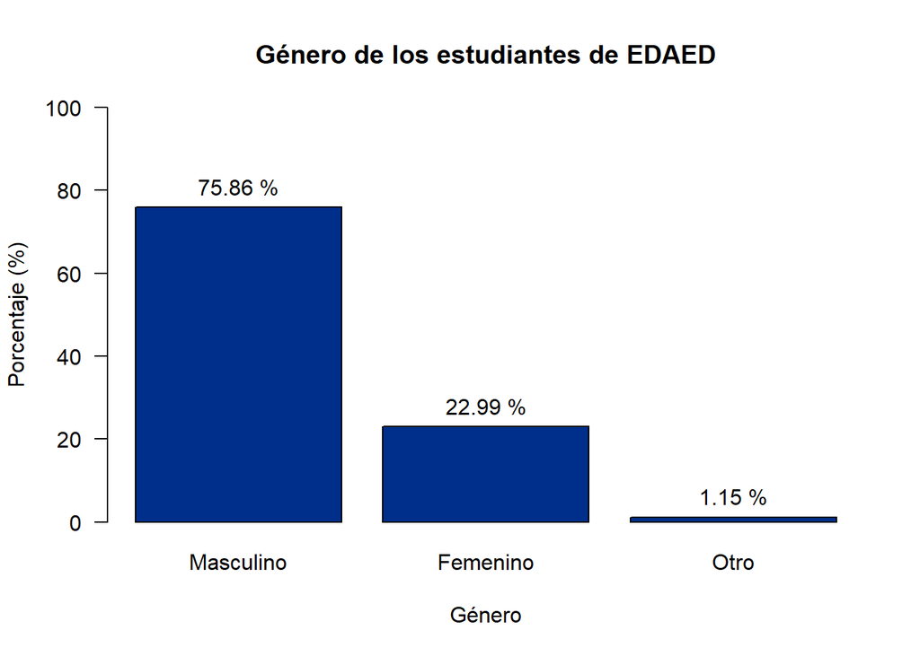

#### 3. Edad

Para analizar la fecha de nacimiento, se va a apelar a la variable auxiliar *edad* que se creó con el objeto de facilitar el análisis de esta variable. Así, como se puede ver a continuación, la edad promedio de los estudiantes de EDAED al 26 de febrero de 2021 era de 21.55 años y tiene su mediana en 20.86 años. Además, el estudiante más joven del curso tiene 17.53 años, mientras que el mayor cuenta con 38.61 años. Además, como se puede observar en el histograma, hay un carácter bimodal en la distribución, pues existen un par de edades que se repiten con mucha frecuencia: una un poco antes de los veinte años y otra hacia los 22.5 años.

```
##    Min. 1st Qu.  Median    Mean 3rd Qu.    Max.
##   17.53   19.40   20.86   21.55   22.56   38.61
```

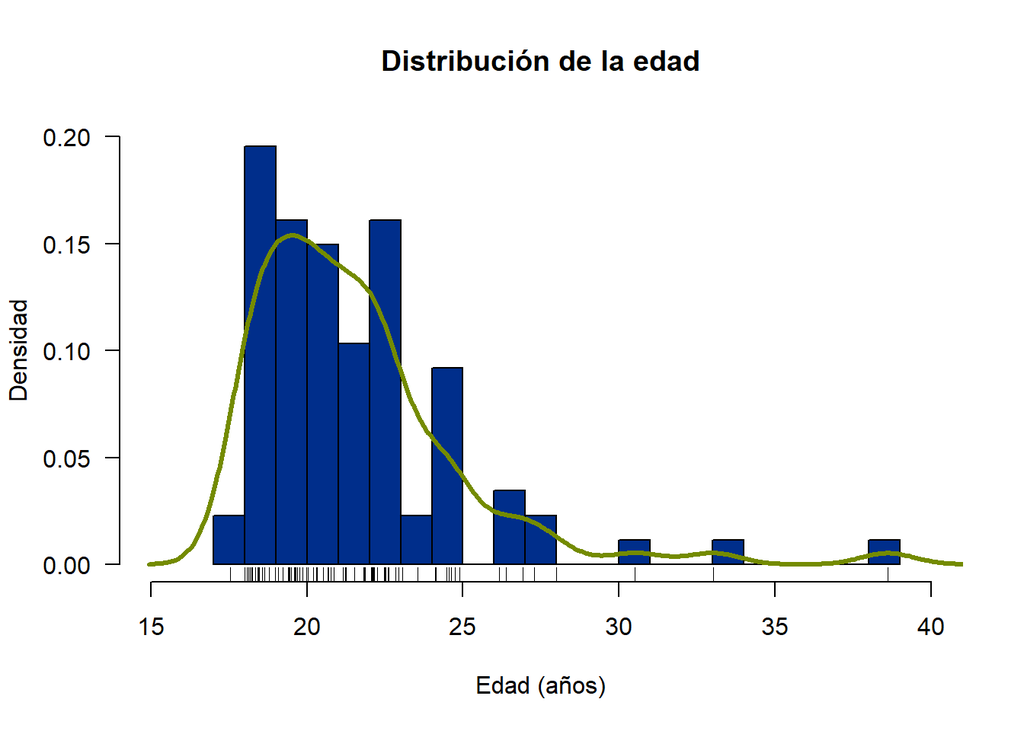

#### 4. Carrera

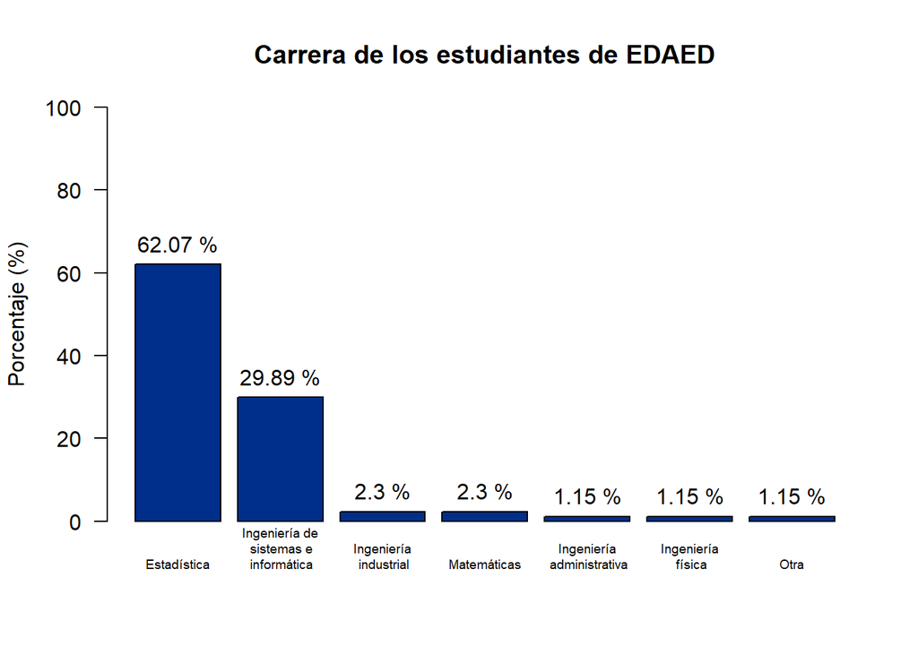

#### 5. Avance en la carrera

Como ya se explicó anteriormente, para el análisis de la variable *semestre* se va a apelar a la conversión *avance*, la cual es una variable continua con un nivel de medición de razón, y como se puede notar a continuación, el estudiante que presenta un menor avance lleva un 15% de créditos aprobados, mientras que el estudiante con más avance alcanza el 80%. Además, es curioso notar que al menos el 75 % de los estudiantes de EDAED presentan un avance igual o menor al 50 %. Por otro lado, en el histograma se puede observar que esta es una variable unimodal, siendo claro que la mayor parte de los estudiantes de este curso apenas están comenzando con sus carreras universitarias.

Es importante destacar que para la definición de la cantidad de clases de este histograma (siete) se empleó la metodología de Sturges.

```
##    Min. 1st Qu.  Median    Mean 3rd Qu.    Max.
##   15.00   20.00   30.00   35.43   50.00   80.00
```

[figure not shown]

#### 6. Puntaje en las pruebas Saber 11

```
##    Min. 1st Qu.  Median    Mean 3rd Qu.    Max.
##     0.0   299.0   327.0   322.7   358.0   500.0
```

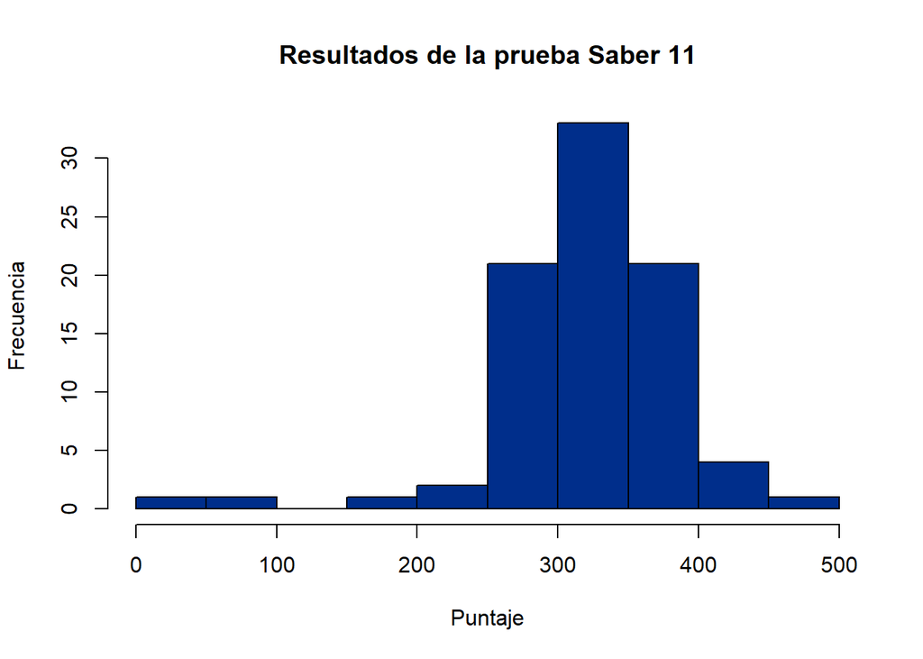

#### 7. Percentil en las pruebas Saber 11

```
##    Min. 1st Qu.  Median    Mean 3rd Qu.    Max.
##    0.00   74.25   88.00   78.94   95.50  100.00
```

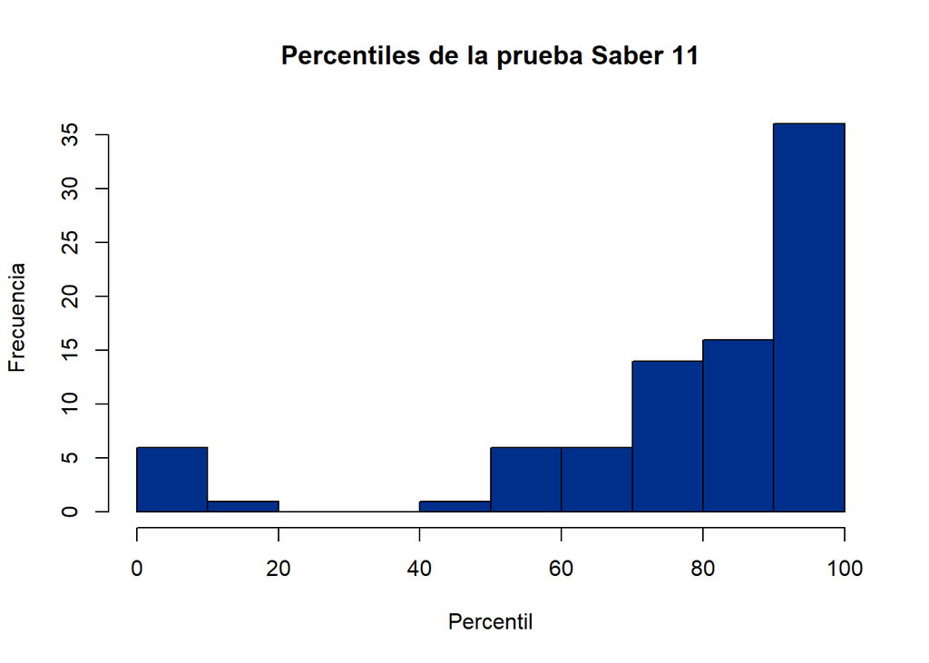

#### 8. Fecha de presentación de las pruebas Saber 11

```
##    Min. 1st Qu.  Median    Mean 3rd Qu.    Max.
##    1999    2015    2017    2016    2018    2019
```

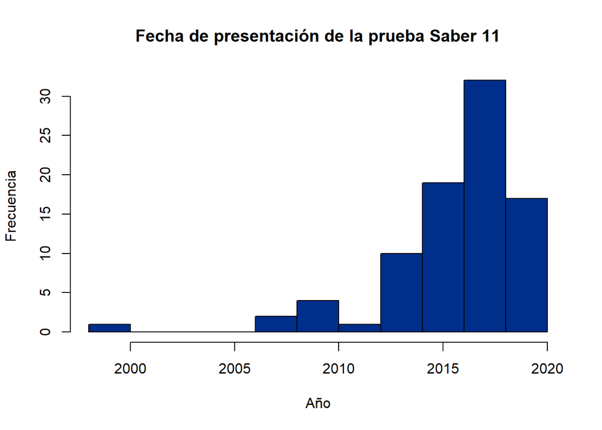

#### 9. PAPA

Corresponde al Promedio Aritmético Ponderado Acumulado de los estudiantes del curso, y vemos que en promedio estos tienen un PAPA de 4.042, donde el mayor PAPA es de 4.7 y el menor es de 3. Además, en la gráfica vemos que la mayoría de los estudiantes del curso tienen un PAPA entre 3.6 y 4.6.

```
##    Min. 1st Qu.  Median    Mean 3rd Qu.    Max.
##   3.000   3.800   4.100   4.042   4.300   4.700
```

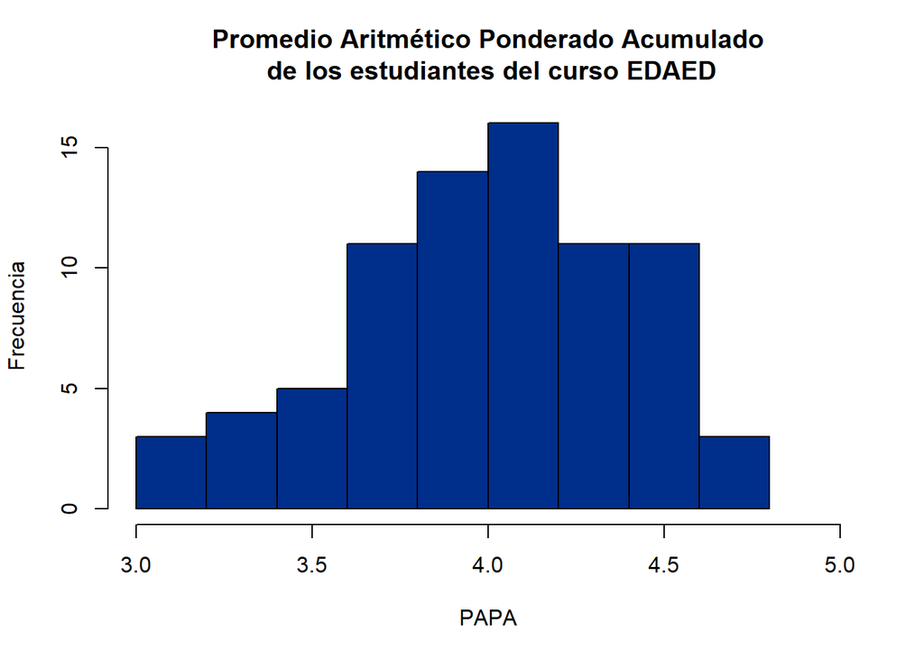

#### 10. Presencia en el Área Metropolitana del Valle de Aburrá

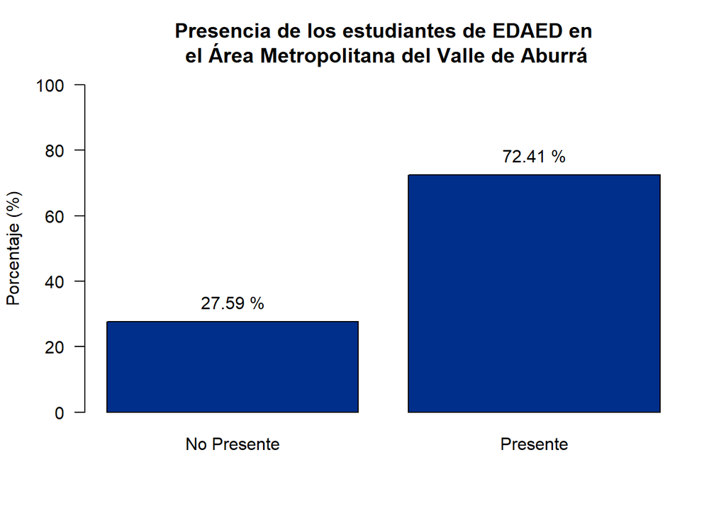

#### 11. Estrato socioeconómico

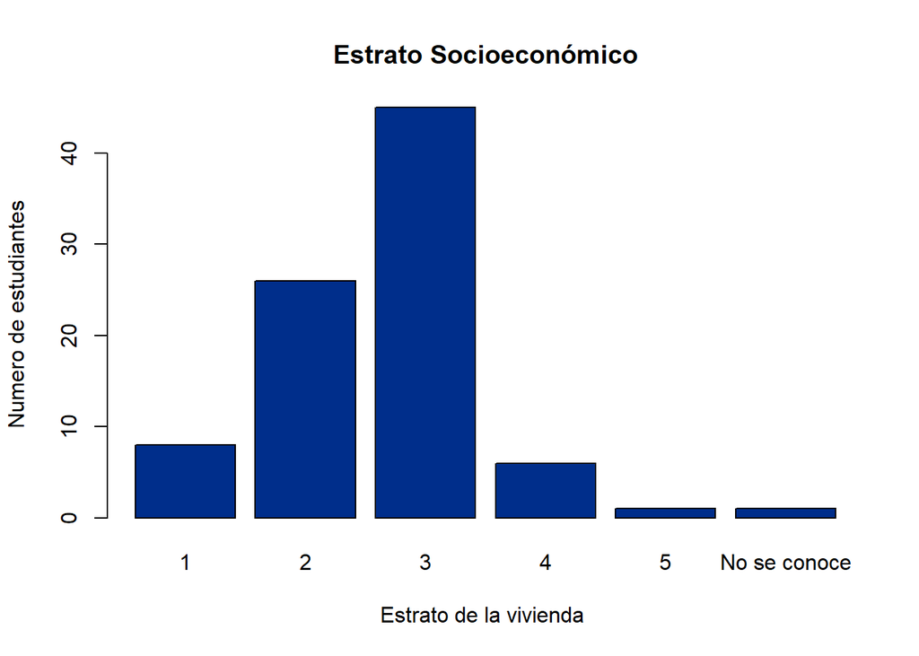

El estrato corresponde en este caso a una variable categórica la cual esta dividida en diferentes clasificaciones. En el caso de la encuesta que se realizó para los estudiantes de EDAED, corresponde desde la clasificacion “1” que seria el estrado más bajo, e iría hasta la clasificación “5” que seria el estrato evidentemente más alto de los estudiantes encuestados. Cabe anotar que al final se observa una clasificacioó algo inusual para las anteriores, siendo esta *“No se conoce”* la cual indica que el estudiante al momento de realizar la encuesta no conocía el estrato al que pertenecia su vivienda. De la tabla podemos evidenciar que los estratos en los cuales se concentran los estudiantes del curso EDAED son los estrados 2 y 3. Además, se observa que hay pocos estudiantes que pertenecen a los estratos 1, 4 y 5.

#### 12. Instalación de R y RStudio

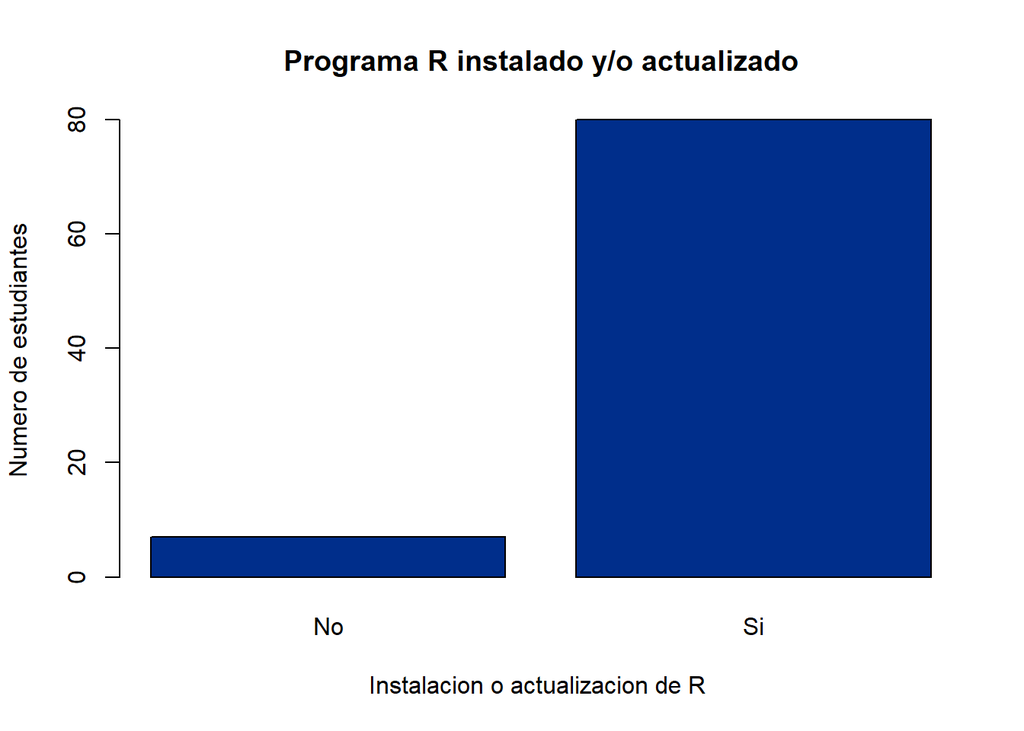

##### **Instalación de R**

```
## No Si
##  7 80
```

##### **Instalación de RStudio**

```
## No Si
## 11 76
```

##### **No instalación de R o RStudio**

```
##
##
##                                                                                                76
##                                                                                                 0
##                                                                                                 1
##                                            Al momento de ingresar me salta en error del software
##                                                                                                 1
##                                     lo tengo instalado pero los paquetes no me los deja instalar.
##                                                                                                 1
##                                                                                               n/a
##                                                                                                 1
## No cuento con capacidad para descargar estos programas, estoy a la espera de un nuevo computador
##                                                                                                 1
##                                  No e podido instalar Rstudio por que mi computador es de 32 bits
##                                                                                                 1
##                                                                                 No hay computador
##                                                                                                 1
##                                                               no me da en mi computador por viejo
##                                                                                                 1
##                                            No por el trabajo no he estado mucho tiempo en mi casa
##                                                                                                 1
##                         RStudio no me permite instalar por que mi sistema operativo es de 32 bits
##                                                                                                 1
##                                                                                           Si pude
##                                                                                                 1
```

Así pues, de acuerdo a la tabla anterior, que hace referencia a no tener en el ordenador ninguno de los programas estadísticos solicitados por el docente de EDAED, de la cual se observa que del total de los 87 estudiantes, 76 sí tenian uno o los dos programas instalados, pero 8 no poseían la forma de tener alguno de los dos software correctamente instalados dado a diversas razones ajenas a la asignatura. Se puede destacar que hubo un estudiante que su respuesta no fue coherente con el fin de la pregunta.

#### 13. Acceso a internet de cable propio

##### **Recursos informáticos: Internet de cable propio**

```
## No Si
## 48 39
```

##### **Recursos informáticos: Internet de cable no propio**

```
## No Si
## 85  2
```

Con respecto a la pregunta de tener internet de cable propio o no y respondiendo a la primera pregunta (“contar con internet de cable propio”), 39 de los estudiantes de EDAED sí lo tenían mientras que 48 de ellos, no. Luego, sobre la segunda pregunta (“no poseer internet de cable propio”), observamos que ya son 85 estudiantes (98%) y el 2% restante sí tiene internet de cable pero no pertenece a ellos como tal.

#### 14. Acceso a Wi-Fi

##### **Recursos informáticos: Wi-Fi propio**

```
## No Si
## 12 75
```

##### **Recursos informáticos: Wi-Fi no propio**

```
## No Si
## 77 10
```

Respecto a la variable relacionada con la pregunta que cuestiona sobre la propiedad de Wi-Fi, se tenían dos opciones de respuesta: propio y no propio. Las tablas muestran que 75 estudiantes de EDAED tenian Wi-Fi propio al momento de la encuesta, cuyo numero equivale de un total de 87 estudiantes al 86 %. El 14% restante no tenía W-iFi propio. Estudiando la otra variable (“Wi-Fi no propio”), se evidencia que 10 personas no tenían Wi-Fi propio en sus hogares (11%)

#### 15. Acceso a red de datos

##### **Recursos informáticos: celular con datos**

```
## No Si
## 61 26
```

##### **Recursos informáticos: celular sin datos**

```
## No Si
## 42 45
```

En la pregunta de celular con datos al momento de la encuesta, 61 estudiantes no contaban con servicio de intenet móvil, mientras que 26 estudiantes sí tenían datos en su celular. Cabe resaltar que la siguiente pregunta sobre si no se tenian datos en el celular, de los estudiantes encuestados, más del 50% no tenáan datos móviles en su celular.

#### 16. Acceso a portátil propio.

##### **Recursos informáticos: portátil propio**

```
## No Si
## 16 71
```

##### **Recursos informáticos: portátil no propio**

```
## No Si
## 81  6
```

71 estudiantes (82 %) de EDAED poseían portátil propio al momento de realizar la encuesta, mientras que 16 de ellos (18 %) no tenían porttil o bien, tenían computador de escritorio. Tomando para el análisis la segunda pregunta (“portátil no propio”), 6 estudiantes contaban con portátil pero no era propio. Se puede decir que un total de 77 estudiantes (89%) contaban con portátil en sus hogares.

#### 17. Computador de escritorio propio y exclusivo

##### **Recursos informáticos: Computador de escritorio propio y exclusivo**

```
## No Si
## 78  9
```

##### **Recursos informáticos: Computador de escritorio no propio pero exclusivo**

```
## No Si
## 86  1
```

##### **Recursos informáticos: Computador de escritorio ni propio ni exclusivo**

```
## No Si
## 83  4
```

##### **Recursos informáticos: Computador de escritorio propio pero no exclusivo**

```
## No Si
## 82  5
```

Según las tablas anteriores, 14 estudiantes contaban al momento de la encuesta con computador propio de escritorio, bien sea exclusivo o no. Por otro lado, cuatro de ellos no contaban con computador de escritorio propio y que fuera exclusivo y solamente 1 estudiante no tenía posesion de un computador de escritorio pero sí era exclusivo.

#### 18. Acceso a tablet con datos

```
## No Si
## 84  3
```

##### **Recursos informáticos: tablet sin datos**

```
## No Si
## 80  7
```

Solamente tres estudiantes tenían acceso a tablet con datos, mientras que otros siete no tenían datos en su tablet.

### Segunda parte de la encuesta

En esta sección se indagarán los resultados relacionados con diversas conspiraciones, siendo algunas falsas y otras verdaderas (debidamente documentadas) y las posiciones de los estudiantes del curso de EDAED respecto a estas.

#### 19. Conspiraciones: Alunizaje

```
## No Si
## 76 11
```

Con respecto a la pregunta que se habia planteado sobre si el hombre había llegado realmente a la Luna o si era un montaje de HollyWood, once personas respondieron erróneamente dicha pregunta, ya que la respuesta correcta fue que el hombre sí había llegado a la Luna, y en este sentido, 76 estudiantes acertaron este interrogante.

#### 20. Conspiraciones: Espionaje en Internet

```
## No Si
## 28 59
```

El 68% de los encuestados (59 estudiantes) estuvieron de acuerdo con que la Agencia de Seguridad Nacional de Estados Unidos estuvo en problemas por crear un proyecto para espiar el internet de los civiles, plan que fue llevado a juicio dado que violaba la libertad de las personas, siendo este un derecho fundamental en tal país, y aparte era ilegal ya que se estaba haciendo sin consentimiento alguno. El 32 % de los encuestados respondió con un “No” dado que no creían tal hecho o tenían desconocimiento sobre este.

#### 21. Conspiraciones: Experimentos en personas afroamericanas

```
## No Si
## 32 55
```

El 63 % de los que respondieron la encuesta contestaron que sí era cierto que se hicieron experimentos en personas afroamericanas mediante la no aplicación de penicilina a la población que padecia de sifilis. El 37% restante de los encuestados no estuvieron de acuerdo a que tal hecho fuese cierto o lo desconocían.

#### 22. Conspiraciones: Vacunas

```
## No Si
## 84  3
```

Entre todos los estudiantes del curso de EDAED,, el 97% está a favor de que las vacunas sirven y no son una conspiración de las multinacionales farmacéuticas para enriquecerse a costillas de estas. Solo el 3% de los encuestados arremete contra las farmacéuticas por su enriquecimiento programado y la no naturalidad de las vacunas en el cuerpo humano.

#### 23. Conspiración: Uso de evidencia falsa por parte del FBI

```
## No Si
## 19 68
```

El 78% de los encuestados respondió acertadamente sobre la cuestión de que el FBI había utilizado evidencia falsa en el siglo pasado para condenar inocentes. Así pues, el 22% restante estuvo en contra de tal postura, considerando falso que el FBI estuviese implicado en acusaciones de tal gravedad.

#### 24. Conspiraciones: Ráfagas solares

```
## No Si
## 67 20
```

Llegando a una pregunta relacionada a la geologia, el 23 % de los encuestados está a favor de que el Sol cumple una función en el movimiento de la Tierra cuando se dan los temidos sismos, de hecho el 77 % de los estudiantes del curso, dice que las ráfagas solares no son los precursores de los sismos de la Tierra dado que realmente estos últimos se dan por la tectónica de las placas de la Tierra y de actividad neotectónica de algunas partes de nuestro planeta.

#### 25. Conspiraciones: Tierra hueca

```
## No Si
## 82  5
```

Casi el la totalidad de los estudiantes encuestados (94 %) afirma rotundamente que la Tierra en su forma física no es hueca y dentro de ella no existe una civilización oculta que los seres humanos tengamos prueba. Solamente el 6% restante afirma lo contrario.

#### 26. Conspiraciones: Alienígenas

```
## No Si
## 56 31
```

La pregunta sobre los alienígenas hace cambiar un poco los resultados. Un poco más de la mitad (64%) respondió “No” a la visita de los alienígenas a las civilizaciones antiguas y su influencia en la historia y aparte de que, según teorias, estos fueron los precursores de las construcciones de los megamonumentos que datan de la antiguedad. El 36 % de los encuestados sí esta totalmente de acuerdo al planteamiento de esta pregunta.

#### 27. Cambio climático.

```
## No Si
## 73 14
```

Esta pregunta es algo controversial a día de hoy, ya que demasiadas personas afirman que la mayoría de industrias son las causantes del cambio climático que ha venido sufriendo la Tierra en los ultimos años. Cabe destacar que el 84 % de los encuestados están en contra de la idea de que el cambio climático que ocurre en la actualidad se dé por procesos naturales. En cambio, El 16 % restante de los encuestados (equivalente a 14 personas) van en contra de esta posición y afirman que lo que ha sufrido la Tierra en los últimos años se debe a un proceso natural.

### Tercera parte de la encuesta

En esta sección final se presenta el análisis descriptivo de las últimas preguntas de la encuesta, preguntas que respondieron los estudiantes del curso de EDAED y que tienen que ver con temas geométricos y algebraicos, además del porcentaje estimado de estudiantes que ellos creían que responderían correctamente a las preguntas.

#### 24. Área de la región sombreada

```
##                      3*pi                      4*pi                    4.5*pi
##                         5                        39                        13
##                      6*pi                    7.5*pi Ninguna de las anteriores
##                         9                         3                        18
```

Se le preguntó a los estudiantes cuál era el área de cierta región sombreada de un circulo, donde el radio del círculo es de 6. La respuesta correcta es "4*pi", por lo que notamos que 39 de los encuestados (lo que corresponde al 45%) respondieron correctamente a la pregunta. Como ya se analizó antes, siendo que los estudiantes del curso son de carreras afines a las matemáticas, sorprende la proporción tan baja de aquellos que respondieron correctamente.

#### 25. Porcentaje de área sombreada

```
##    Min. 1st Qu.  Median    Mean 3rd Qu.    Max.    NA's
##    3.00   30.75   50.00   52.36   70.00  100.00       1
```

Esta vez se le preguntó a los estudiantes por el porcentaje del curso de EDAED que ellos consideraban había contestado acertadamente la pregunta del área sombreada. Vemos que en promedio el porcentaje que estimaron es del 52%, que es un porcentaje muy cercano al real que fue de 45%. Esto se comprueba en el siguiente histograma, donde se ve que una porción grande del curso acertó al estimar este porcentaje.

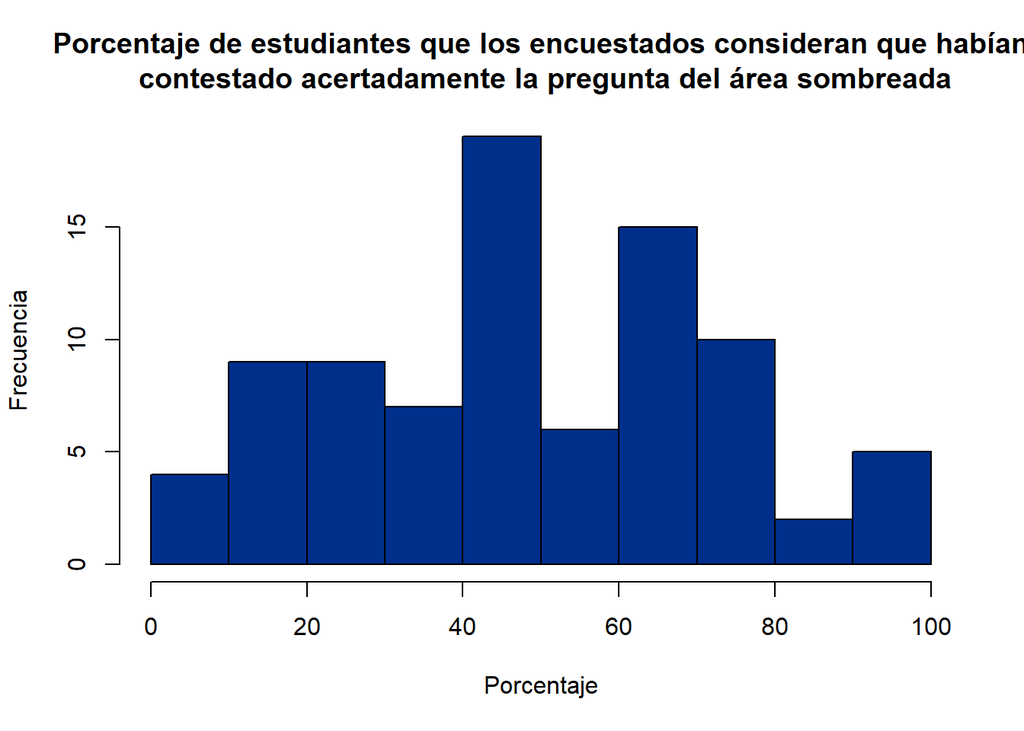

#### 26. Divisor

Se le hizo a los estudiantes la siguiente pregunta: “Si f, g y h son todos número enteros positivos y f es divisor de g y g es divisor de h entonces marque las sentencias que son correctas”, donde la primera opción fue “f es divisor de g^2”, la segunda “f es divisor de gh” y la tercera “f es divisor de h-g”. Como se dijo anteriormente, dado que las tres opciones son correctas se optó por la creación de una nueva variable que almacenara la cantidad de opciones que seleccionaron los estudiantes, y se obtuvo lo siguiente:

```
##  1  2  3
## 39 28 20
```

Como vemos, el número de estudiantes que respondieron correctamente la pregunta es sí fue de 20, lo que corresponde al 23% de los estudiantes del curso de EDAED y, al igual que con la pregunta del área sombreada, es un porcentaje sorprendentemente bajo dadas las carreras a las que pertenecen dichos estudiantes.

#### 27. Porcentaje de divisor

```
##    Min. 1st Qu.  Median    Mean 3rd Qu.    Max.
##    2.00   35.00   60.00   54.03   70.00  100.00
```

Al igual que con la pregunta del área sombreada, se le preguntó a los encuestados por el porcentaje de estudiantes del curso de EDAED que ellos consideraban había contestado acertadamente la pregunta del divisor. Vemos que en promedio el porcentaje que estimaron es del 54%, que es un porcentaje alejado del real que fue de 23%. Esto se comprueba en el siguiente histograma, donde se ve que una gran parte del curso consideró un porcentaje de entre 40 y 80 por ciento.

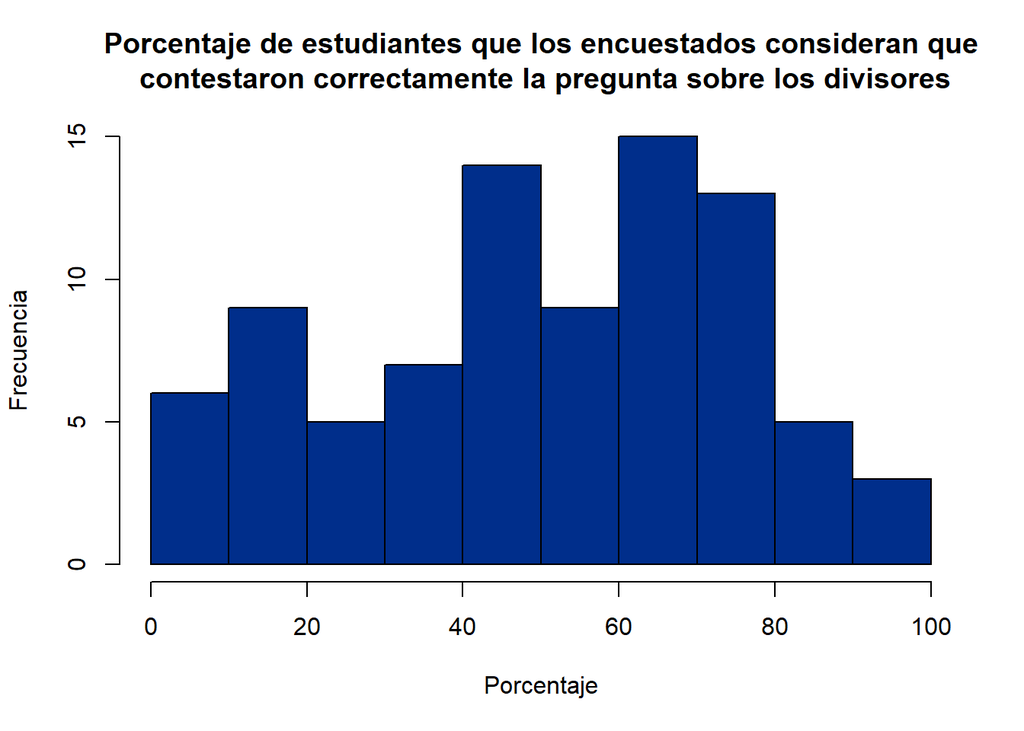

## Análisis exploratorio. Cruces bivariados

### Primera pregunta

*¿Existe alguna relación entre la creencia en diversas conspiraciones falsas y el PAPA?*

Como grupo, pensamos que aquellos estudiantes que suelen creer en conspiraciones falsas pueden tener un PAPA menor a aquellos estudiantes que no creen en estas conspiraciones. También se piensa que, dentro de los que creen en conspiraciones falsas, tendrán un peor PAPA aquellos estudiantes que crean en una mayor cantidad de las conspiraciones por las que se preguntó en la encuesta.

#### Resumen numérico

```
##                 Intervalos del PAPA
## # Conspiraciones [3,3.5] (3.5,4] (4,4.5] (4.5,5]
##                0       7       9      12       5
##                1       0      10      14       1
##                2       2       6       6       1
##                3       0       0       2       0
##                4       0       2       0       0
##                5       1       0       0       0
```

##### Resumen del PAPA para la creencia en 0 conspiraciones falsas:

```
##    Min. 1st Qu.  Median    Mean 3rd Qu.    Max.    NA's
##   3.000   3.800   4.100   4.018   4.300   4.700       3
```

##### Resumen del PAPA para la creencia en 1 conspiración falsa:

```
##    Min. 1st Qu.  Median    Mean 3rd Qu.    Max.    NA's
##   3.600   3.900   4.200   4.152   4.400   4.700       3
```

##### Resumen del PAPA para la creencia en 2 conspiraciones falsas:

```
##    Min. 1st Qu.  Median    Mean 3rd Qu.    Max.    NA's
##    3.00    3.70    4.00    3.98    4.25    4.70       2
```

##### Resumen del PAPA para la creencia en 3 conspiraciones falsas:

```
##    Min. 1st Qu.  Median    Mean 3rd Qu.    Max.    NA's
##   4.100   4.125   4.150   4.150   4.175   4.200       1
```

##### Resumen del PAPA para la creencia en 4 conspiraciones falsas:

```
##    Min. 1st Qu.  Median    Mean 3rd Qu.    Max.
##   3.700   3.775   3.850   3.850   3.925   4.000
```

##### Resumen del PAPA para la creencia en 5 conspiraciones falsas:

```
##    Min. 1st Qu.  Median    Mean 3rd Qu.    Max.
##     3.2     3.2     3.2     3.2     3.2     3.2
```

#### Gráfica exploratoria

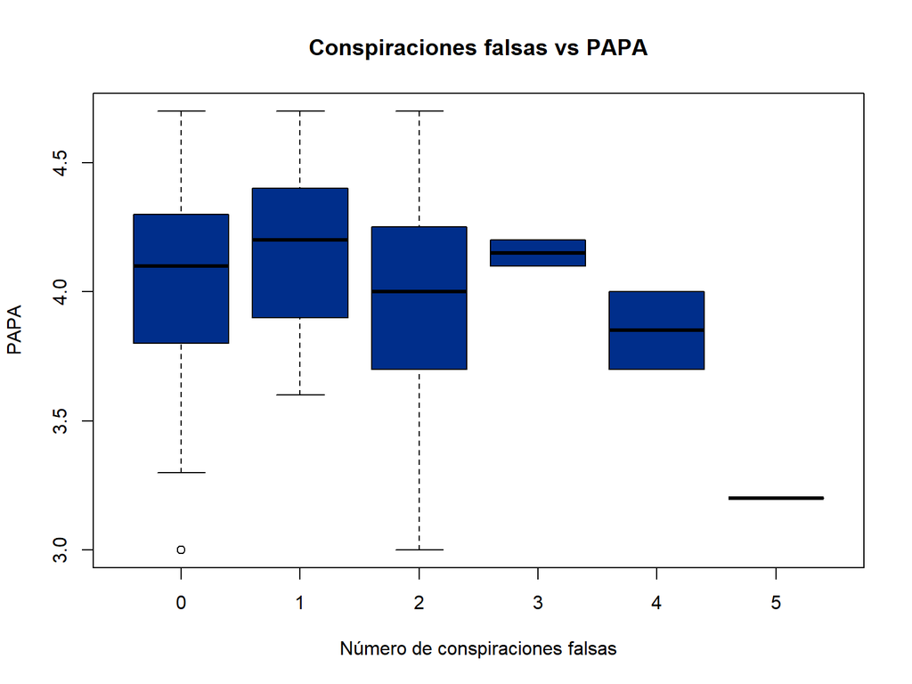

#### Análisis

Tambien es de notar la poca población para la creencia en 3 o más conspiraciones falsas, por lo que no se logra apreciar de forma general que el número de conspiraciones falsas en que creen los estudiantes influya negativamente en su respectivo PAPA. Además, gracias a los resúmenes numéricos, se puede decir que 5 de los 7 estudiantes con un PAPA de clasificación “Superior” (Entre 4.5 y 5) no creen en ninguna de las conspiraciones consideradas como falsas.

También se observa que las cajas son inicialmente altas, lo que quiere decir que el rango intercuartídico es alto y que, en consecuencia, existe una gran dispersión de los datos para el cruce de este par de variables, lo cual podría respaldar la idea de que finalmente no existe tal relación.

### Segunda pregunta

*¿Tienen los estudiantes de estratos superiores (cuatro, cinco y seis) un mejor PAPA que aquellos de estratos inferiores (uno, dos y tres)?*

La pregunta lo dice todo: se piensa inicialmente que aquellos estudiantes que son de mayor estrato tenderán a tener un PAPA más alto, mientras que los de menor estrato a tener un PAPA algo más bajo, esto porque debido a las necesidades económicas de cada quien se le puede dedicar o no más tiempo al estudio, además que de acuerdo al estrato se deduce que aquellos de mayor estrato han tenido una mejor formación académica, posiblemente privada, mientras que la de los estratos más bajos pudo haber sido más deficiente. Sin embargo, se tiene en cuenta que el resultado puede llegar a ser todo lo contrario, y que los de estratos más bajos podrían tener mejor PAPA por el esfuerzo que dedican al estudio o buenas prácticas para estudiar, entre muchos otros más factores.

#### Resumen numérico

```
##               Intervalos del PAPA
## Estrato        [3,3.5] (3.5,4] (4,4.5] (4.5,5]
##   1                  1       2       2       0
##   2                  3       8       9       4
##   3                  6      15      17       3
##   4                  0       2       4       0
##   5                  0       0       1       0
##   No se conoce       0       0       1       0
```

##### Resumen del PAPA para el Estrato 1:

```
##    Min. 1st Qu.  Median    Mean 3rd Qu.    Max.    NA's
##     3.2     3.7     3.7     3.8     4.2     4.2       3
```

##### Resumen del PAPA para el Estrato 2:

```
##    Min. 1st Qu.  Median    Mean 3rd Qu.    Max.    NA's
##   3.000   3.800   4.100   4.067   4.350   4.700       2
```

##### Resumen del PAPA para el Estrato 3:

```
##    Min. 1st Qu.  Median    Mean 3rd Qu.    Max.    NA's
##   3.000   3.800   4.000   4.029   4.300   4.600       4
```

##### Resumen del PAPA para el Estrato 4:

```
##    Min. 1st Qu.  Median    Mean 3rd Qu.    Max.
##   4.000   4.025   4.100   4.167   4.250   4.500
```

##### Resumen del PAPA para el Estrato 5:

```
##    Min. 1st Qu.  Median    Mean 3rd Qu.    Max.
##     4.3     4.3     4.3     4.3     4.3     4.3
```

#### Gráficas exploratorias

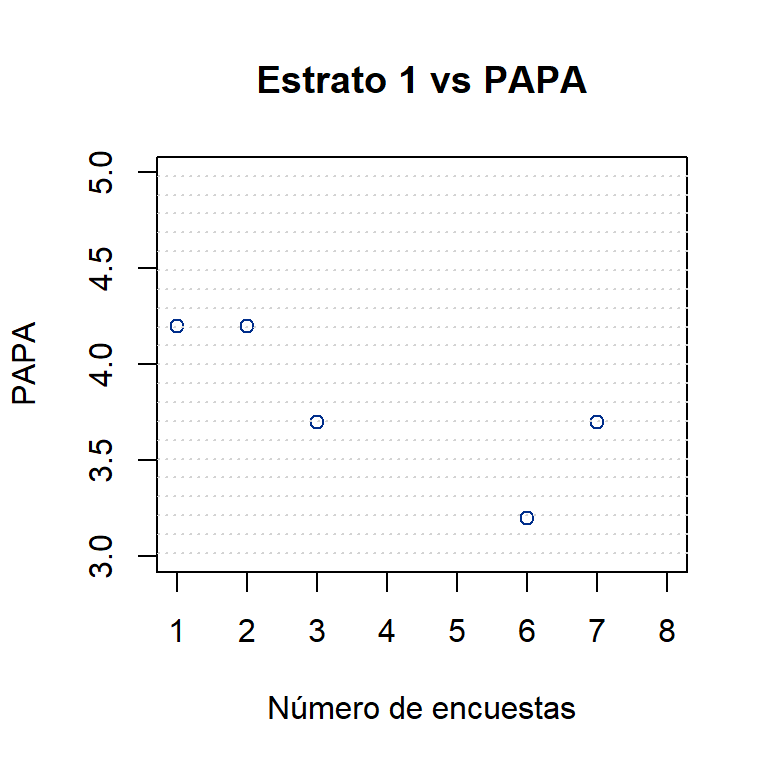

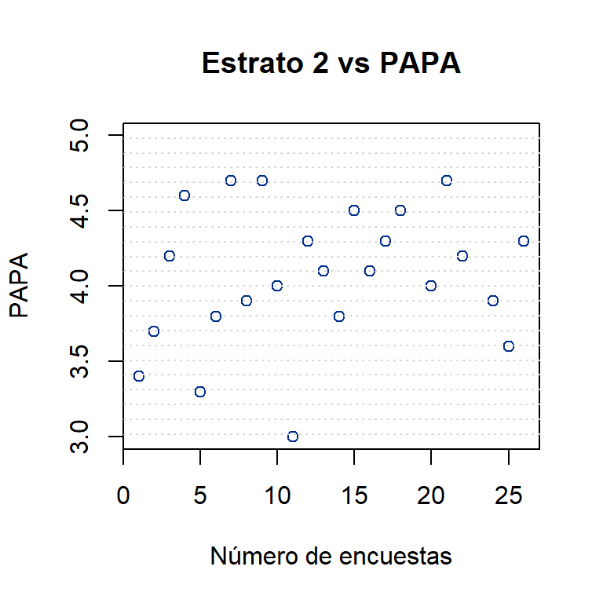

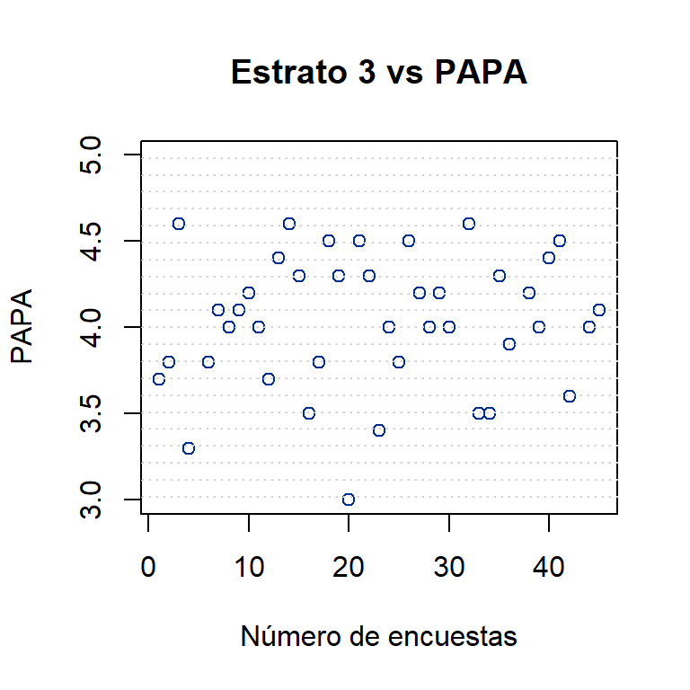

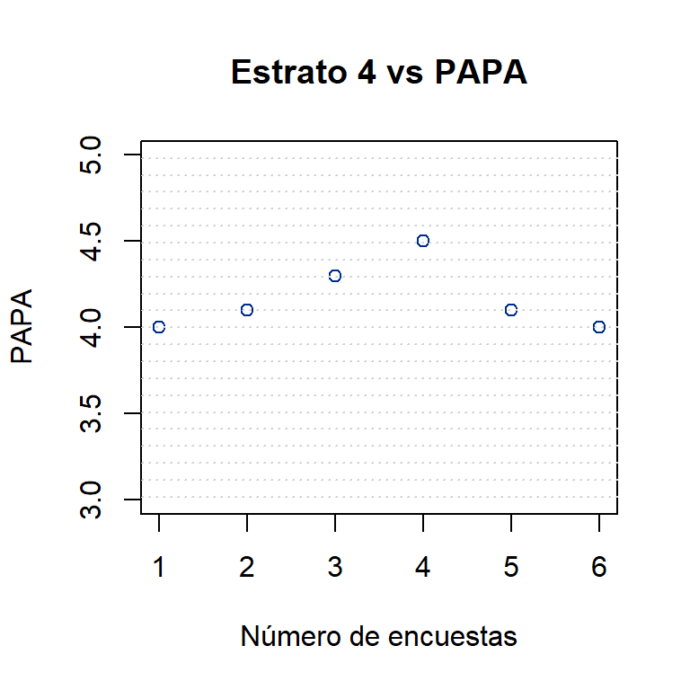

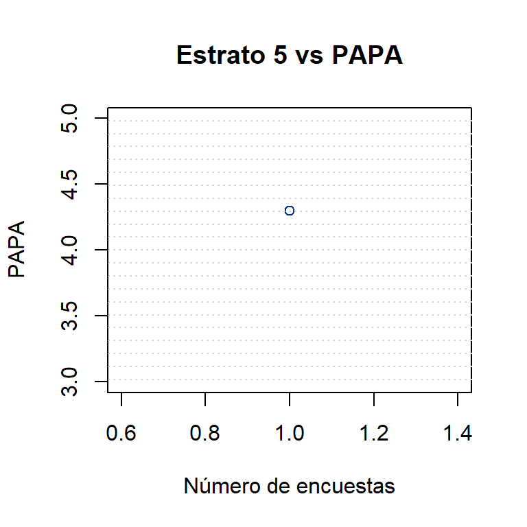

### Tercera pregunta

*¿El número de recursos tecnológicos propios que poseen los estudiantes depende del estrato al que pertenecen?*

Como dice la pregunta, se plantea el supuesto de que aquellos estudiantes que tengan mayor número de recursos tecnológicos propios pertenecerán a un estrato más alto que aquellos que tengan menos recursos tecnológicos propios disponibles.

#### Resumen numérico

```
##               Número de recursos propios
## Estrato         0  1  2  3  4  5
##   1             2  2  4  0  0  0
##   2             2  1 13  8  2  0
##   3             0  2 14 19  6  4
##   4             0  0  1  1  2  2
##   5             0  0  0  1  0  0
##   No se conoce  0  0  1  0  0  0
```

##### Resumen de número de recursos tecnológicos propios para el Estrato 1:

```
##    Min. 1st Qu.  Median    Mean 3rd Qu.    Max.
##    0.00    0.75    1.50    1.25    2.00    2.00
```

##### Resume de número de recursos tecnológicos propios para el Estrato 2:

```
##    Min. 1st Qu.  Median    Mean 3rd Qu.    Max.
##   0.000   2.000   2.000   2.269   3.000   4.000
```

##### Resumen de número de recursos tecnológicos propios para el Estrato 3:

```
##    Min. 1st Qu.  Median    Mean 3rd Qu.    Max.
##   1.000   2.000   3.000   2.911   3.000   5.000
```

##### Resumen de número de recursos tecnológicos propios para el Estrato 4:

```
##    Min. 1st Qu.  Median    Mean 3rd Qu.    Max.
##   2.000   3.250   4.000   3.833   4.750   5.000
```

##### Resumen de número de recursos tecnológicos propios para el Estrato 5:

```
##    Min. 1st Qu.  Median    Mean 3rd Qu.    Max.
##       3       3       3       3       3       3
```

#### Gráficas exploratorias

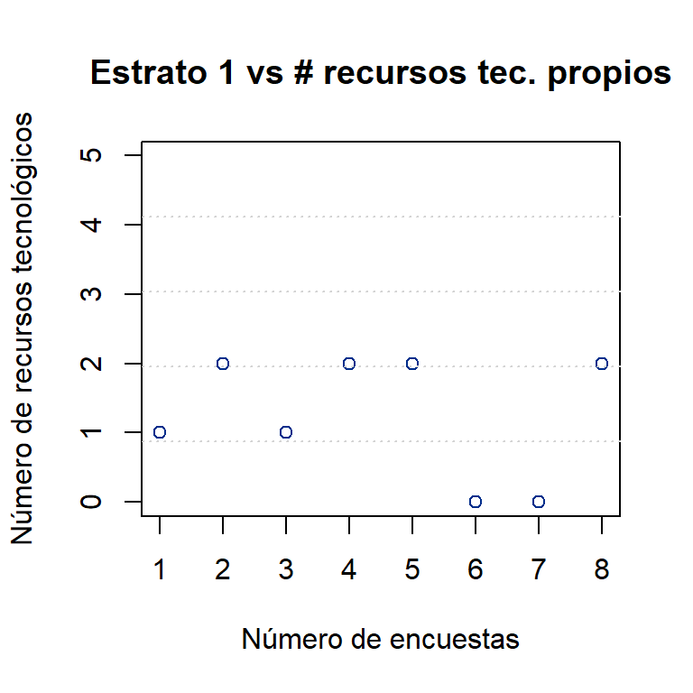

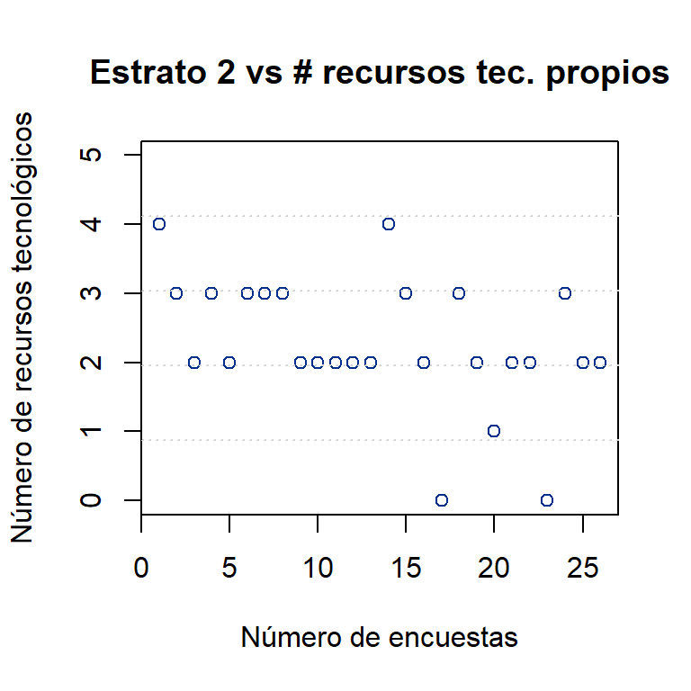

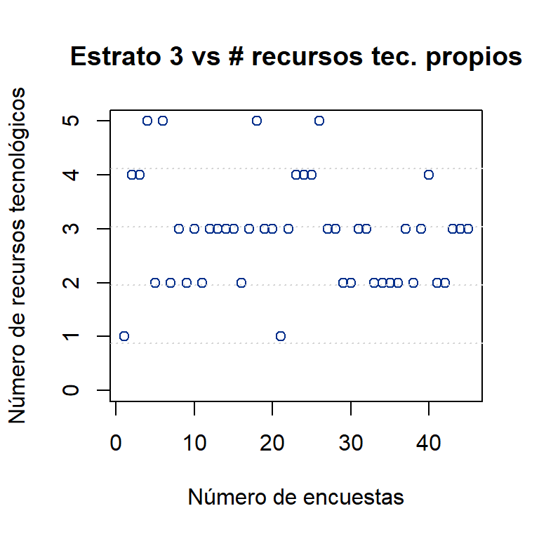

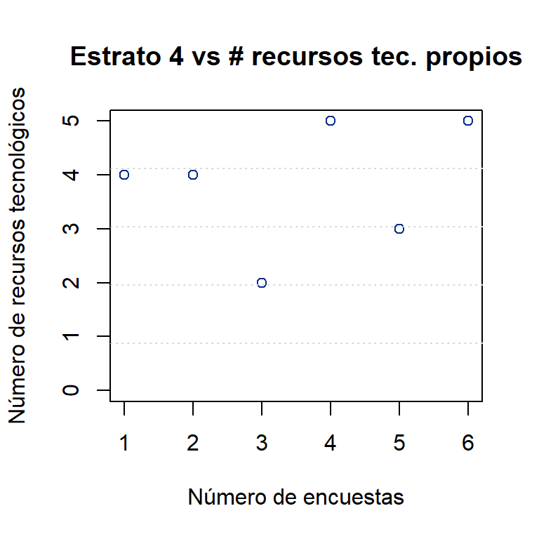

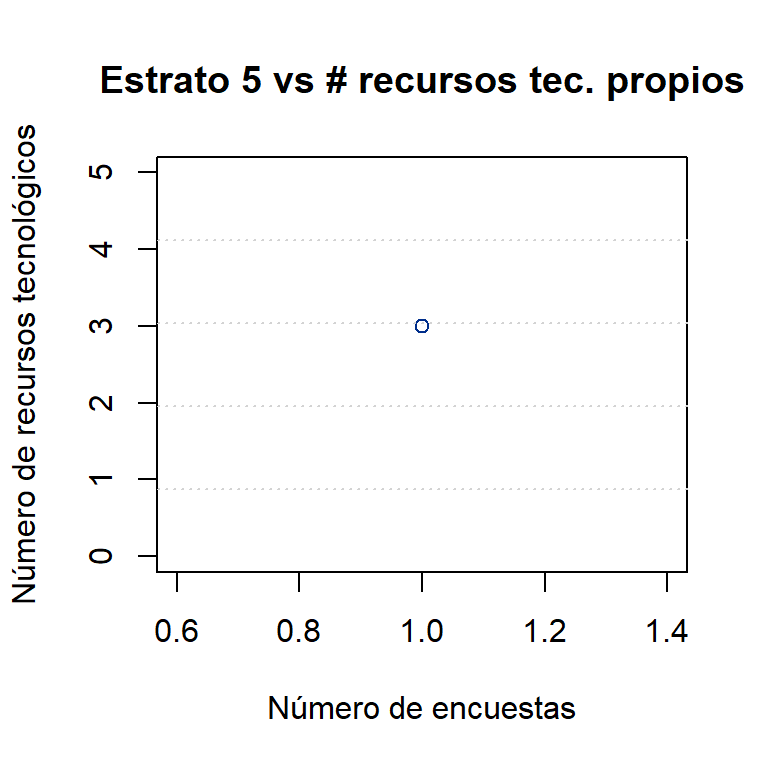

#### Análisis

En los resúmenes numéricos se ve que, conforme el estrato de los estudiantes aumenta, el número de recursos tecnológicos propios en promedio con que cuentan estos estudiantes tiende a aumentar. Dicha tendencia se verifica también en las gráficas, donde para los estratos más bajos los recursos tecnológicos propios son menos, mientras que el número de estudiantes con estos recursos empieza a aumentar para estratos más altos. Por lo tanto, se verifica la hipótesis y se concluye que el número de recursos tecnológicos propios que poseen los estudiantes sí depende del estrato al que pertenecen, pues a mayor estrato, mayor número de recursos tecnológicos propios se poseen en promedio.

## Análisis exploratorio. Cruces multivariados

### Cuarta pregunta

*¿Son los estudiantes con mayor avance en la carrera los que respondieron mejor las preguntas de álgebra y/o geometría?*

Inicialmente se cree que aquellos estudiantes que tengan un mayor avance en su carrera hayan respondido correctamente las preguntas sobre el área sombreada y/o los divisores; en otras palabras, se piensa que aquellos que tengan un menor avance en su carreras habrán respondido incorrectamente dichas preguntas. Recordar que la respuesta correcta del área sombreada es *"4*pi"*, además que solamente quienes hallan seleccionado las tres opciones en la pregunta de los divisores habrán respondido correctamente en su totalidad esa pregunta.

#### Resumen numérico: Área sombreada

```
##                            Intervalos de avance en la carrera
## Selección área sombreada    [10,20] (20,30] (30,40] (40,50] (50,60] (60,70]
##   3*pi                            2       0       1       1       0       0
##   4*pi                           15       3       5       5       4       6
##   4.5*pi                          5       4       3       1       0       0
##   6*pi                            5       2       2       0       0       0
##   7.5*pi                          2       0       1       0       0       0
##   Ninguna de las anteriores       9       0       2       1       2       1
##                            Intervalos de avance en la carrera
## Selección área sombreada    (70,80]
##   3*pi                            0
##   4*pi                            1
##   4.5*pi                          0
##   6*pi                            0
##   7.5*pi                          0
##   Ninguna de las anteriores       3
```

##### Resumen del avance en la carrera para los que respondieron correctamente la pregunta del área sombreada:

```
##    Min. 1st Qu.  Median    Mean 3rd Qu.    Max.
##   15.00   20.00   40.00   39.28   52.50   75.00
```

##### Resumen del avance en la carrera para los que respondieron incorrectamente la pregunta del área sombreada:

```
##    Min. 1st Qu.  Median    Mean 3rd Qu.    Max.    NA's
##   15.00   20.00   25.00   32.23   40.00   80.00       1
```

#### Resumen numérico: Divisores

```
##                   Intervalos de avance en la carrera
## Número de opciones [10,20] (20,30] (30,40] (40,50] (50,60] (60,70] (70,80]
##                  1      25       3       3       4       1       3       0
##                  2       6       5       6       2       3       2       3
##                  3       7       1       5       2       2       2       1
```

##### Resumen del avance en la carrera para los que respondieron correctamente la pregunta de los divisores:

```
##    Min. 1st Qu.  Median    Mean 3rd Qu.    Max.
##   15.00   20.00   37.50   38.65   51.25   75.00
```

##### Resumen del avance en la carrera para los que respondieron incorrectamente la pregunta de los divisores:

```
##    Min. 1st Qu.  Median    Mean 3rd Qu.    Max.    NA's
##   15.00   20.00   25.00   34.45   45.75   80.00       1
```

#### Gráficas exploratorias

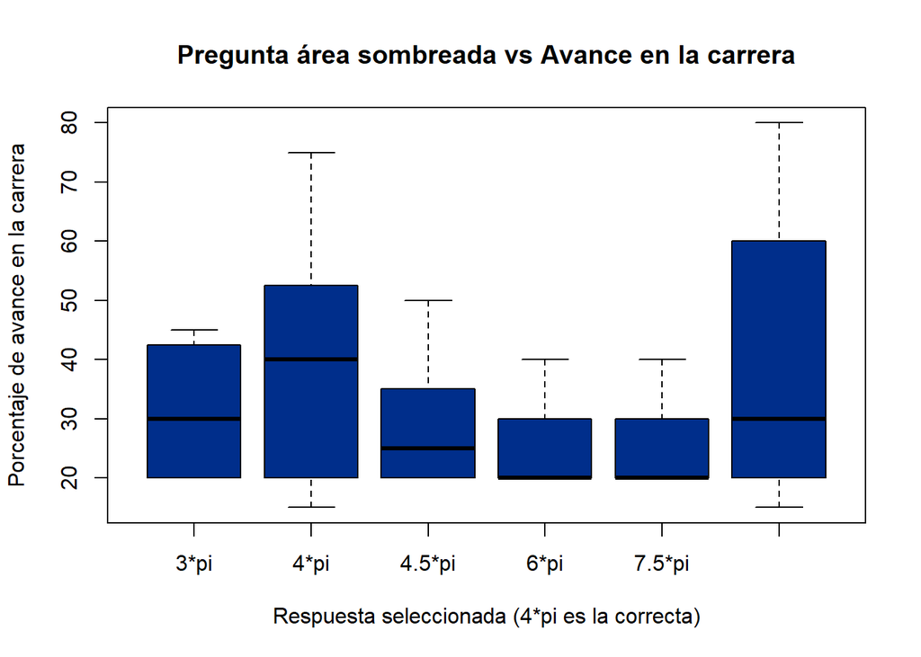

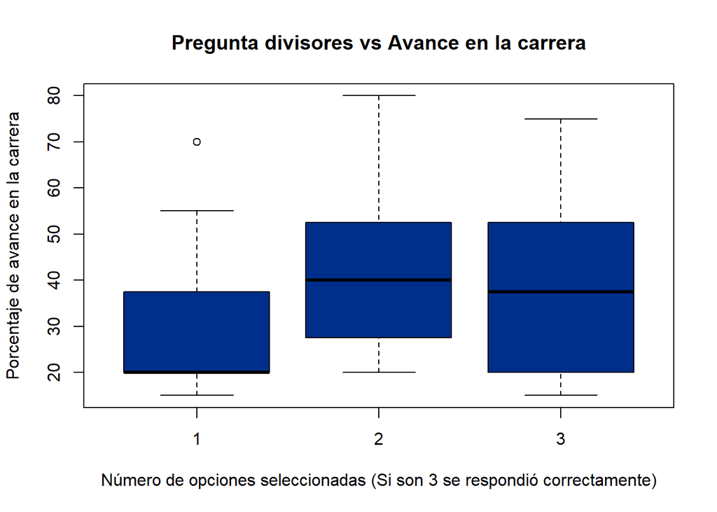

#### Análisis

En el primer boxplot se observa que que no hay diferencias en promedio en el avance en la carrera y la respuesta seleccionada en la pregunta de geometría incluida en la tercera parte de la encuesta realizada a los estudiantes de EDAED, pero en este caso se puede observar que la respuesta correcta, 4pi y la respuesta “Ninguna de las anteriores”, que corresponde a la última caja del primer boxplot, son las que presentan mayor dispersión en sus respuestas, mientras que las respuestas 6pi y 7.5pi son las de menor dispersión.

Por otro lado, en el segundo boxplot, que esquematiza a la pregunta de los divisores y el avance, nuevamente se observa que no hay diferencias en promedio para los tres casos posibles y que la dispersión es relativamente alta para cada uno de esos casos.

Respecto a la pregunta planteada, se descarta la respuesta sugerida para esta, pues se observa que hay bigotes que llegan a lo alto ambas tablas, siendo esto indicador de que existen estudiantes con avance considerable que respondieron incorrectamente las preguntas de geometría o de manera incompleta las de álgebra.

### Quinta pregunta

*¿Hay alguna relación entre la edad, el PAPA y el género de los estudiantes?*

Como grupo, consideramos que mientras más edad tengan los estudiantes, más alto será su PAPA, ya que mientras más madurez presente la persona más responsabilidad obtiene, sobretodo si se trata de las mujeres, por lo que esperemos que esto se vea reflejado al analizar los resúmenes y las gráfica. Más específicamente, esperamos que los estudiantes de género femenino tengan PAPA más alto que los estudiantes de género masculino, y dentro de estos casos, se espera que aquellos estudiantes de mayor edad sean los que presenten los PAPAs más altos. No se tomará en cuenta el género “Otro” por encontrarse una única vez en la encuesta.

#### Resumen numérico: Género Masculino

```
##                    Intervalos del PAPA
## Edad Hombres (Años) [3,3.5] (3.5,4] (4,4.5] (4.5,5]
##                  18       3       2       3       1
##                  19       0       2       4       0
##                  20       1       3       6       1
##                  21       3       1       4       0
##                  22       1       3       2       1
##                  23       1       3       2       0
##                  24       0       2       2       1
##                  25       0       0       2       0
##                  26       0       0       0       0
##                  27       0       1       1       0
##                  28       0       1       0       0
##                  31       0       1       0       0
##                  33       0       0       1       0
##                  39       1       0       0       0
```

##### Resumen de la edad de los estudiantes de género masculino:

```
##    Min. 1st Qu.  Median    Mean 3rd Qu.    Max.
##   17.53   19.52   20.86   21.75   22.79   38.61
```

##### Resumen del PAPA de los estudiantes de género masculino:

```
##    Min. 1st Qu.  Median    Mean 3rd Qu.    Max.    NA's
##   3.000   3.775   4.100   4.003   4.300   4.600       6
```

#### Resumen numérico: Género Femenino

```
##                    Intervalos del PAPA
## Edad Mujeres (Años) [3,3.5] (3.5,4] (4,4.5] (4.5,5]
##                  18       0       2       1       0
##                  19       0       0       2       1
##                  20       0       0       1       1
##                  21       0       2       0       0
##                  22       0       2       2       1
##                  25       0       0       1       0
##                  26       0       1       0       0
```

##### Resumen de la edad de las estudiantes de género femenino:

```
##    Min. 1st Qu.  Median    Mean 3rd Qu.    Max.
##   18.12   19.20   20.69   21.02   22.32   26.17
```

##### Resumen del PAPA de las estudiantes de género femenino:

```
##    Min. 1st Qu.  Median    Mean 3rd Qu.    Max.    NA's
##   3.600   4.000   4.200   4.182   4.500   4.700       3
```

#### Gráfica exploratoria

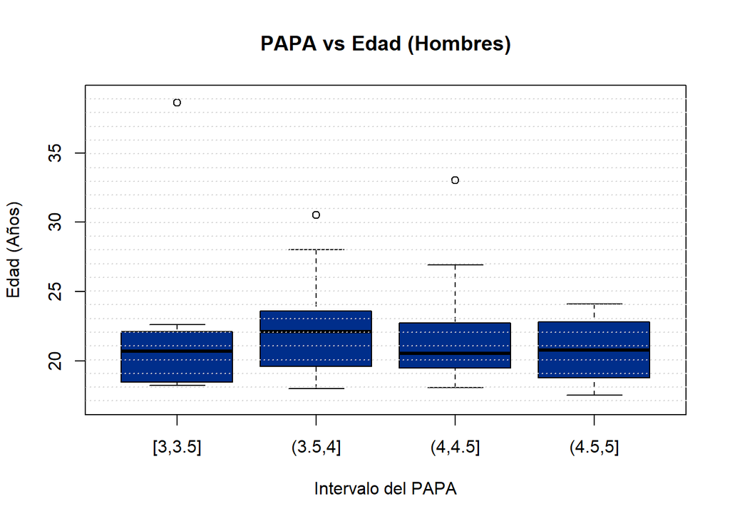

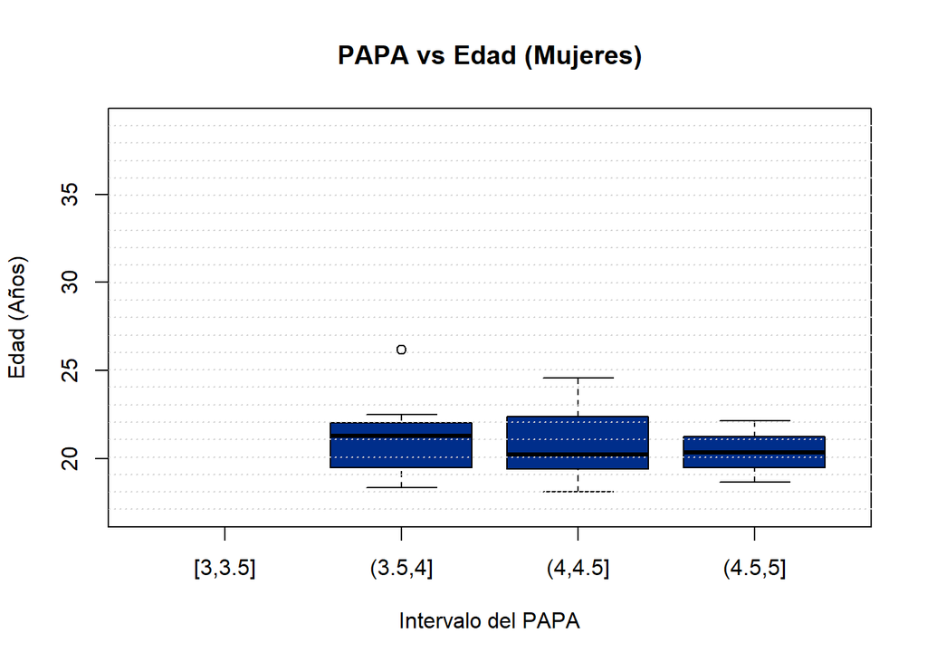

#### Análisis

Por otro lado, en las gráficas se ve que el rango de edad para los PAPAs más altos es relativamente menor que el rango de edad para los PAPAs intermedios, por lo que los estudiantes de mayor edad no necesariamente tienen un PAPA más alto que el resto del curso. Así se concluye que las mujeres en general presentaron mejor PAPA que los hombres, mientras que el PAPA no depende de la edad del estudiante.